# Introducción a la Dendrocronología en R

##### Instrucciones

En cada sección podrás ejecutar y analizar los comandos básicos para leer, visualizar y realizar los análisis básicos utilizados en Dendrocronología. La mayoría de análisis que se llevaran acabo son iguales o muy similares a los que se realizan en los programas originales programados en FORTRAN llamados COFECHA y ARSTAN. En este caso utilizaremos el ambiente de R y utilizaremos el paquete `dplR` programado y desarrollado por Andy Bunn y Mikko Korpela en el 2014 pueden bajar el articulo dándole clic al siguiente enlace. https://drive.google.com/uc?export=download&id=1ps7tZ0RTwuIr2P_h-ugHkbgAs3Jrdxaa

La idea y objetivo principal de estos ejercicios es que puedas familiarizarte con este tipo de ambiente, y puedas aprender haciendo. A lo largo de este documento hay un set de comandos y ejercicios que podrás ejecutar y modificar con tus propios archivos y o mediciones. Si lo modificaste y necesitas el archivo original lo puedes clonar de nuevo desde la pagina de github. https://github.com/paulszejner/Intro_dendrocrono.git

A continuación vamos a instalar y activar el `dplR` y se conectaran a la base de datos disponibles del international Tree Ring Data Bank (ITRDB) mediante la web

El primer paso de buenas costumbres y buenas practicas es iniciar con el ambiente de R limpio utilizando el comando `rm(list=ls())` podrás limpiar todos los objetos que pueden estar activos en tu consola.

```r
install.packages(dplR)
```

```
Error in install.packages : object 'dplR' not found
```

```r
library(dplR) # librería para análisis dendrocronológicos

Dat_ringwidth <-  read.rwl("https://www.ncei.noaa.gov/pub/data/paleo/treering/measurements/northamerica/mexico/mexi042.rwl")
```

```
Attempting to automatically detect format.
Assuming a Tucson format file.
There appears to be a header in the rwl file
There are 20 series
1       RAN01A       1950    2006   0.001
2       RAN01B       1929    2006   0.001
3       RAN02A       1957    2006   0.001
4       RAN02B       1933    2006   0.001
5       RAN03A       1929    2006   0.001
6       RAN03B       1942    2006   0.001
7       RAN04A       1921    2006   0.001
8       RAN05A       1925    2006   0.001
9       RAN05B       1934    2006   0.001
10      RAN06A       1925    2006   0.001
11      RAN07A       1924    2006   0.001
12      RAN07B       1918    2006   0.001
13      RAN08A       1913    2006   0.001
14      RAN08B       1913    2006   0.001
15      RAN09A       1913    2006   0.001
16      RAN09B       1913    2006   0.001
17      RAN10A       1865    2006   0.001
18      RAN11B       1946    2006   0.001
19      RAN12A       1936    2006   0.001
20      RAN12B       1936    2006   0.001
```

```r
Dat_Earlywood <- read.rwl("https://www.ncei.noaa.gov/pub/data/paleo/treering/measurements/northamerica/mexico/mexi042e.rwl")
```

```
Attempting to automatically detect format.
Assuming a Tucson format file.
There appears to be a header in the rwl file
There are 20 series
1       RAN01A       1950    2006   0.001
2       RAN01B       1929    2006   0.001
3       RAN02A       1957    2006   0.001
4       RAN02B       1933    2006   0.001
5       RAN03A       1929    2006   0.001
6       RAN03B       1942    2006   0.001
7       RAN04A       1921    2006   0.001
8       RAN05A       1925    2006   0.001
9       RAN05B       1934    2006   0.001
10      RAN06A       1925    2006   0.001
11      RAN07A       1924    2006   0.001
12      RAN07B       1918    2006   0.001
13      RAN08A       1913    2006   0.001
14      RAN08B       1913    2006   0.001
15      RAN09A       1913    2006   0.001
16      RAN09B       1913    2006   0.001
17      RAN10A       1865    2006   0.001
18      RAN11B       1946    2006   0.001
19      RAN12A       1936    2006   0.001
20      RAN12B       1936    2006   0.001
```

```r
Dat_latewood <- read.rwl("https://www.ncei.noaa.gov/pub/data/paleo/treering/measurements/northamerica/mexico/mexi042l.rwl")
```

```
Attempting to automatically detect format.
Assuming a Tucson format file.
There appears to be a header in the rwl file
There are 17 series
1       RAN02A       1960    2006   0.001
2       RAN02B       1933    2006   0.001
3       RAN03A       1929    2006   0.001
4       RAN03B       1942    2006   0.001
5       RAN04A       1921    2006   0.001
6       RAN05A       1925    2006   0.001
7       RAN05B       1934    2006   0.001
8       RAN06A       1925    2006   0.001
9       RAN07A       1924    2006   0.001
10      RAN07B       1918    2006   0.001
11      RAN08A       1913    2006   0.001
12      RAN09A       1913    2006   0.001
13      RAN09B       1913    2006   0.001
14      RAN10A       1865    2006   0.001
15      RAN11B       1946    2006   0.001
16      RAN12A       1936    2006   0.001
17      RAN12B       1936    2006   0.001
```

```r
# También se puede bajar  desde los FPTs del NOAA
# Dat_ftp <- read.rwl("ftp://ftp.ncdc.noaa.gov/pub/Data/paleo/treering/measurements/northamerica/mexico/mexi042.rwl")

str(Dat_ringwidth) # la función str te da la estructura del objeto llamado Datos
```

```
Classes ‘rwl’ and 'data.frame': 142 obs. of  20 variables:
 $ RAN01A: num  NA NA NA NA NA NA NA NA NA NA ...
 $ RAN01B: num  NA NA NA NA NA NA NA NA NA NA ...
 $ RAN02A: num  NA NA NA NA NA NA NA NA NA NA ...
 $ RAN02B: num  NA NA NA NA NA NA NA NA NA NA ...
 $ RAN03A: num  NA NA NA NA NA NA NA NA NA NA ...
 $ RAN03B: num  NA NA NA NA NA NA NA NA NA NA ...
 $ RAN04A: num  NA NA NA NA NA NA NA NA NA NA ...
 $ RAN05A: num  NA NA NA NA NA NA NA NA NA NA ...
 $ RAN05B: num  NA NA NA NA NA NA NA NA NA NA ...
 $ RAN06A: num  NA NA NA NA NA NA NA NA NA NA ...
 $ RAN07A: num  NA NA NA NA NA NA NA NA NA NA ...
 $ RAN07B: num  NA NA NA NA NA NA NA NA NA NA ...
 $ RAN08A: num  NA NA NA NA NA NA NA NA NA NA ...
 $ RAN08B: num  NA NA NA NA NA NA NA NA NA NA ...
 $ RAN09A: num  NA NA NA NA NA NA NA NA NA NA ...
 $ RAN09B: num  NA NA NA NA NA NA NA NA NA NA ...
 $ RAN10A: num  1.08 1.47 1.7 1.08 1.48 ...
 $ RAN11B: num  NA NA NA NA NA NA NA NA NA NA ...
 $ RAN12A: num  NA NA NA NA NA NA NA NA NA NA ...
 $ RAN12B: num  NA NA NA NA NA NA NA NA NA NA ...
```

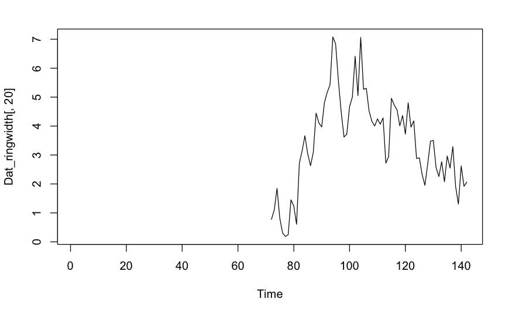

```r
### Grafica los datos para el control de calidad -------------------------------

plot.ts(Dat_ringwidth[,20])
```

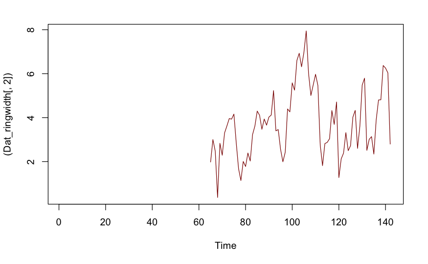

```r
plot.ts((Dat_ringwidth[,2]), col="darkred")
```

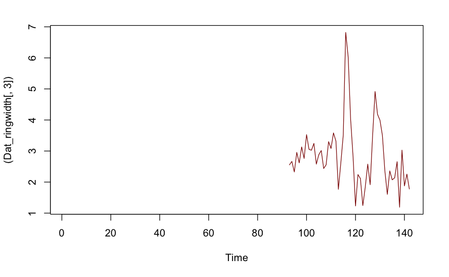

```r
plot.ts((Dat_ringwidth[,3]), col="darkred")
```

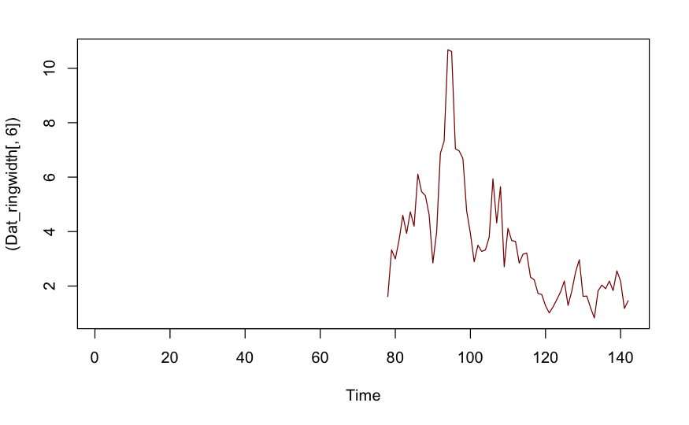

```r
plot.ts((Dat_ringwidth[,6]), col="darkred")
```

#### cuantas series de tiempo están en este archivo?

Podemos revisar todos los detalles del archivo con el cual vamos a trabajar

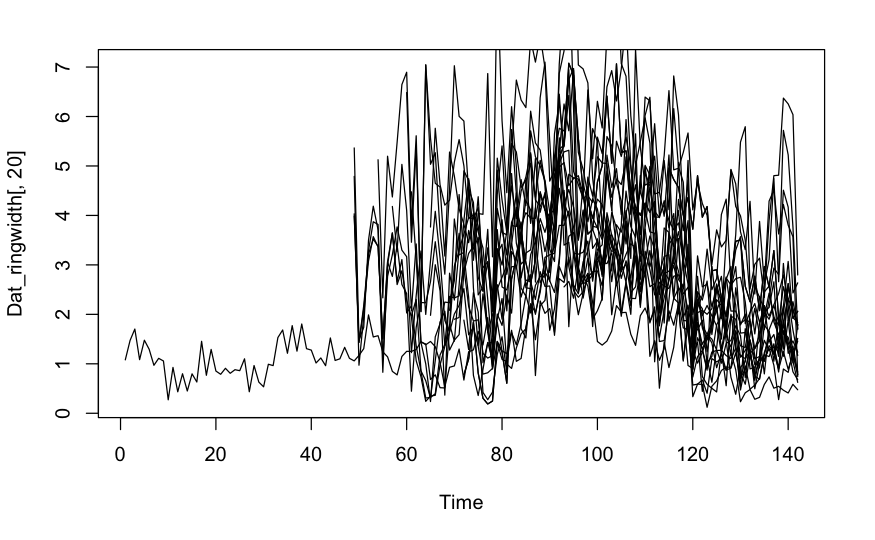

```r
# cuantas series de tiempo están en este archivo? preguntando cuantas columnas  tenemos  es una forma de responder la pregunta
n_series <- ncol(Dat_ringwidth)
# ahora hacemos un plot con todas las serias  en su estado crudo o RAW  sin ningún tratamiento alguno
plot.ts(Dat_ringwidth[,20])
for(s in 1:n_series){lines(Dat_ringwidth[,s]) } # esta forma de  plotear todas las series es un for loop  usando cada columna  en cada uno de los loops
```

En dplR hay otras opciones para graficar los datos que tenemos. Por ejemplo con mas orden y con algunas características que pueden ser útiles. La funcion que se utiliza es el famoso spaguetti plot `spag.plot` funcion del `dplR`

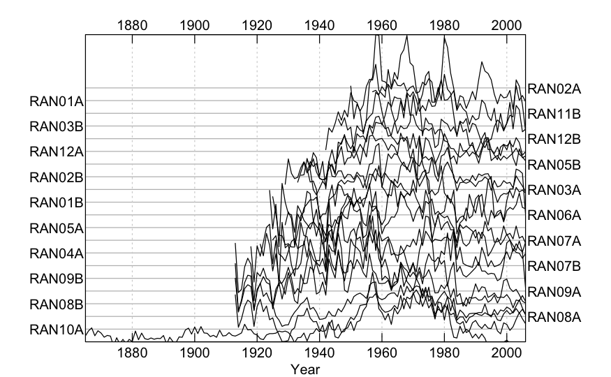

```r
spag.plot(Dat_ringwidth, zfac = 1)
```

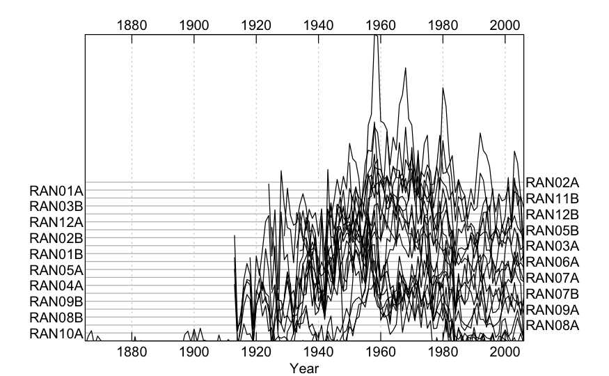

```r
spag.plot(Dat_ringwidth, zfac = 3)
```

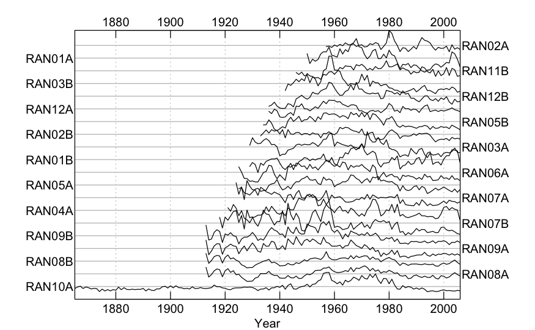

```r
spag.plot(Dat_ringwidth, zfac = 0.3)
```

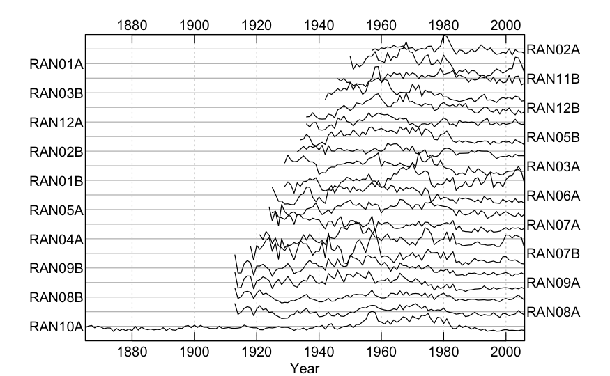

```r
spag.plot(Dat_Earlywood, zfac = 0.3)
```

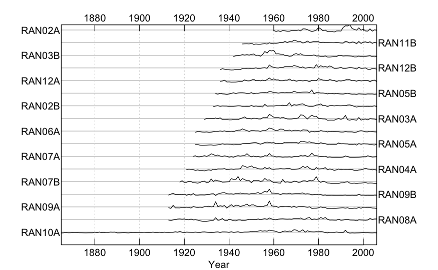

```r
spag.plot(Dat_latewood, zfac = 0.3)
```

#### Como corroboramos el cofechado?

Luego de fechar visualmente las muestras de madera, se procede a su medición, Durante la medición se pueden cometer algunos errores, lo cual puede perjudicar la señal común de los árboles. Por lo tanto debemos corroborar las correlaciones entre todas las series antes de proceder a cualquier análisis.

```r
#simple correlación entre series y series con su periodo en común
cor_matrix <- round(cor(Dat_ringwidth, use = "pairwise"), digits = 2) # la función cor  va  a utilizar una matriz o un data frame  para calcular  las correlaciones entre todas las columnas presentes en la base de datos. generando una matriz cuadrada  con le numero de columnas y  filas  igual al número de series.
cor_matrix
```

```
       RAN01A RAN01B RAN02A RAN02B RAN03A RAN03B RAN04A RAN05A RAN05B RAN06A RAN07A RAN07B RAN08A RAN08B RAN09A RAN09B RAN10A
RAN01A   1.00   0.54   0.19   0.50   0.56   0.50   0.35   0.70   0.78   0.67   0.47   0.42   0.79   0.80   0.60   0.56   0.74
RAN01B   0.54   1.00   0.16   0.24   0.07   0.05   0.24   0.34   0.30   0.28  -0.18  -0.20   0.51   0.51   0.09   0.07   0.35
RAN02A   0.19   0.16   1.00   0.52   0.16   0.05   0.28   0.26   0.30   0.11   0.27   0.15   0.22   0.28   0.17   0.15   0.24
RAN02B   0.50   0.24   0.52   1.00   0.32   0.41   0.22   0.37   0.45   0.53   0.35   0.32   0.33   0.40   0.55   0.44   0.35
RAN03A   0.56   0.07   0.16   0.32   1.00   0.79   0.41   0.53   0.68   0.51   0.61   0.56   0.52   0.58   0.55   0.62   0.58
RAN03B   0.50   0.05   0.05   0.41   0.79   1.00   0.47   0.58   0.73   0.80   0.58   0.62   0.55   0.61   0.66   0.79   0.61
RAN04A   0.35   0.24   0.28   0.22   0.41   0.47   1.00   0.63   0.48   0.56   0.18   0.34   0.37   0.51   0.58   0.61   0.34
RAN05A   0.70   0.34   0.26   0.37   0.53   0.58   0.63   1.00   0.72   0.63   0.06   0.23   0.70   0.76   0.50   0.59   0.71
RAN05B   0.78   0.30   0.30   0.45   0.68   0.73   0.48   0.72   1.00   0.83   0.41   0.42   0.75   0.82   0.60   0.63   0.79
RAN06A   0.67   0.28   0.11   0.53   0.51   0.80   0.56   0.63   0.83   1.00   0.20   0.43   0.59   0.68   0.67   0.69   0.60
RAN07A   0.47  -0.18   0.27   0.35   0.61   0.58   0.18   0.06   0.41   0.20   1.00   0.66  -0.04   0.05   0.45   0.38   0.10
RAN07B   0.42  -0.20   0.15   0.32   0.56   0.62   0.34   0.23   0.42   0.43   0.66   1.00   0.25   0.28   0.62   0.65   0.31
RAN08A   0.79   0.51   0.22   0.33   0.52   0.55   0.37   0.70   0.75   0.59  -0.04   0.25   1.00   0.93   0.35   0.46   0.66
RAN08B   0.80   0.51   0.28   0.40   0.58   0.61   0.51   0.76   0.82   0.68   0.05   0.28   0.93   1.00   0.45   0.51   0.60
RAN09A   0.60   0.09   0.17   0.55   0.55   0.66   0.58   0.50   0.60   0.67   0.45   0.62   0.35   0.45   1.00   0.89   0.35
RAN09B   0.56   0.07   0.15   0.44   0.62   0.79   0.61   0.59   0.63   0.69   0.38   0.65   0.46   0.51   0.89   1.00   0.51
RAN10A   0.74   0.35   0.24   0.35   0.58   0.61   0.34   0.71   0.79   0.60   0.10   0.31   0.66   0.60   0.35   0.51   1.00
RAN11B   0.33   0.24   0.44   0.31   0.01  -0.14  -0.32   0.13   0.14  -0.10  -0.02  -0.15   0.27   0.17  -0.27  -0.30   0.25
RAN12A   0.41   0.15   0.28   0.29   0.37   0.58   0.25   0.32   0.48   0.48   0.08   0.09   0.39   0.48   0.24   0.29   0.36
RAN12B   0.63   0.33   0.20   0.24   0.45   0.53   0.17   0.51   0.67   0.47   0.02   0.12   0.70   0.70   0.17   0.24   0.67
       RAN11B RAN12A RAN12B
RAN01A   0.33   0.41   0.63
RAN01B   0.24   0.15   0.33
RAN02A   0.44   0.28   0.20
RAN02B   0.31   0.29   0.24
RAN03A   0.01   0.37   0.45
RAN03B  -0.14   0.58   0.53
RAN04A  -0.32   0.25   0.17
RAN05A   0.13   0.32   0.51
RAN05B   0.14   0.48   0.67
RAN06A  -0.10   0.48   0.47
RAN07A  -0.02   0.08   0.02
RAN07B  -0.15   0.09   0.12
RAN08A   0.27   0.39   0.70
RAN08B   0.17   0.48   0.70
RAN09A  -0.27   0.24   0.17
RAN09B  -0.30   0.29   0.24
RAN10A   0.25   0.36   0.67
RAN11B   1.00  -0.04   0.30
RAN12A  -0.04   1.00   0.71
RAN12B   0.30   0.71   1.00
```

```r
diag(cor_matrix)  #La función ¨diag¨ solamente extrae un el vector  diagonal  de  una matriz cuadrada,  y en este caso estamos sacando la correlación entre la misma serie. y por eso  deberíamos  obtener  el valor de 1 en toda la diagonal ya que estamos comparando lo mismo con lo mismo.
```

```
RAN01A RAN01B RAN02A RAN02B RAN03A RAN03B RAN04A RAN05A RAN05B RAN06A RAN07A RAN07B RAN08A RAN08B RAN09A RAN09B RAN10A RAN11B
     1      1      1      1      1      1      1      1      1      1      1      1      1      1      1      1      1      1
RAN12A RAN12B
     1      1
```

Hay funciones en el `dplR` que pueden generar resultados muy similares a los de COFECHA, el cual es un programa que evalúa la sincronicidad de todas las series entre si. para hacer esta evaluación se dividen las series en segmentos correlativos y traslapados, para evaluar las correlaciones de todas las muestras por segmentos y sin tendencias que pueden sesgar los coeficientes de correlación.

A continuación se generaran unos ejemplos usando la función del `dplR` llamada `corr.rwl.seg` siempre es bueno poder utilizar los ejemplos que el mismo paquete provee. los cuales pueden acceder utilizando el siguiente comando, `?corr.rwl.seg` en donde pueden leer todo sobre la función, y en la parte inferior de la pagina de ayuda verán algunos ejemplos que se pueden ejecutar en la consola.

En los siguientes ejemplos podrás ver que se ejecuta la misma función pero con diferentes argumentos. (los argumentos son los detalles que definirán como se evalúa y ejecuta la función). por ejemplo acá podemos aclarar el largo del segmento que se utiliza para comparar cada serie con el resto de las series `seg.length=10`, como también podemos indicarle que se remueva toda la autocorrelación que puede existir en las series `prewhiten = T`, generar un gráfico representando los resultados `make.plot = T` y delimitar el limite de confianza para su evaluación estadística `pcrit = 0.1`

nota: los colores rojos en las figuras indican los segmentos que presentan correlaciones por debajo del limite de confianza que se exije.

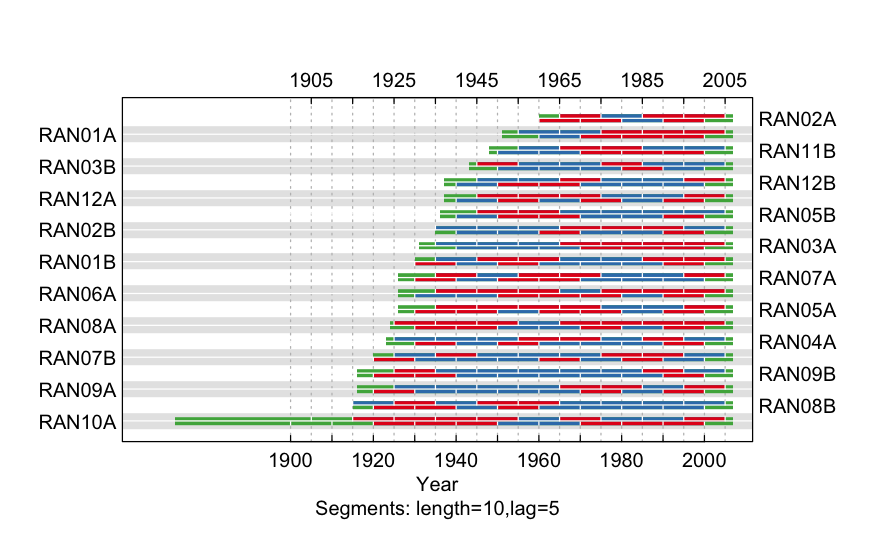

```r
COFECHA_p_0.1 <- corr.rwl.seg(rwl = Dat_ringwidth, seg.length = 10, prewhiten = T, biweight = T, make.plot = T, pcrit = 0.1)
```

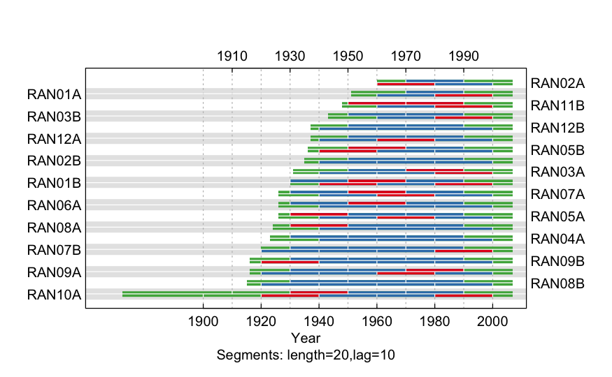

```r
COFECHA_p_0.1 <- corr.rwl.seg(rwl = Dat_ringwidth, seg.length = 20, prewhiten = T, biweight = T, make.plot = T, pcrit = 0.1)
```

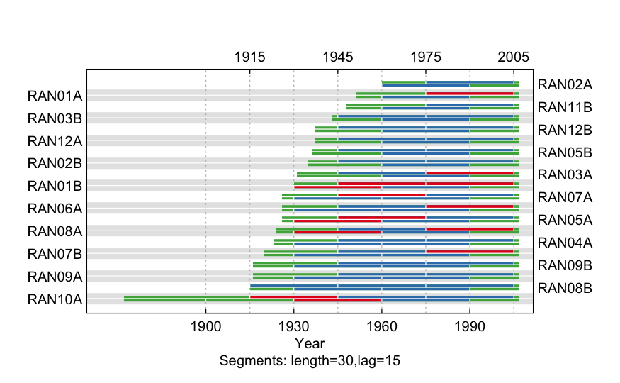

```r
COFECHA_p_0.05 <- corr.rwl.seg(rwl = Dat_ringwidth, seg.length = 30, prewhiten = T, biweight = T, make.plot = T, pcrit = 0.05)
```

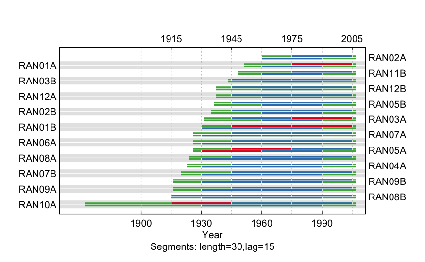

```r
COFECHA_p_0.1 <- corr.rwl.seg(rwl = Dat_ringwidth, seg.length = 30, prewhiten = T, biweight = T, make.plot = T, pcrit = 0.1)
```

De todas las opciones que se pueden ejecutar, qué puedes concluir de este tipo de análisis? -que argumentos son importantes? -de que nos sirve este tipo de análisis?

```r
COFECHA_p_0.1
```

```
$spearman.rho
       1900.1929 1915.1944 1930.1959 1945.1974 1960.1989  1975.2004
RAN01A        NA        NA        NA        NA 0.5052280 0.18620690
RAN01B        NA        NA 0.2556174 0.2142380 0.5924360 0.17775306
RAN02A        NA        NA        NA        NA 0.4896552 0.65250278
RAN02B        NA        NA        NA 0.4327030 0.4371524 0.38242492
RAN03A        NA        NA        NA 0.4967742 0.3147942 0.07897664
RAN03B        NA        NA        NA 0.5537264 0.4994438 0.36907675
RAN04A        NA        NA 0.4251390 0.4909900 0.6275862 0.66451613
RAN05A        NA        NA 0.1390434 0.2262514 0.4037820 0.39532814
RAN05B        NA        NA        NA 0.3619577 0.5688543 0.53058954
RAN06A        NA        NA 0.4233593 0.3971079 0.4518354 0.24983315
RAN07A        NA        NA 0.3294772 0.2840934 0.4371524 0.46963293
RAN07B        NA        NA 0.5715239 0.6907675 0.3810901 0.26318131
RAN08A        NA        NA 0.3023359 0.4745273 0.4665184 0.27919911
RAN08B        NA 0.5639600 0.3948832 0.3971079 0.6235818 0.52880979
RAN09A        NA        NA 0.5101224 0.4438265 0.3486096 0.38553949
RAN09B        NA        NA 0.6200222 0.6796440 0.5595106 0.57196885
RAN10A        NA 0.1350389 0.3005562 0.3241379 0.4527253 0.44115684
RAN11B        NA        NA        NA        NA 0.3788654 0.44382647
RAN12A        NA        NA        NA 0.3543938 0.3971079 0.49410456
RAN12B        NA        NA        NA 0.5648498 0.4936596 0.37931034

$p.val
       1900.1929    1915.1944    1930.1959    1945.1974    1960.1989    1975.2004
RAN01A        NA           NA           NA           NA 0.0024487314 1.615356e-01
RAN01B        NA           NA 0.0861259490 1.272391e-01 0.0003551341 1.729172e-01
RAN02A        NA           NA           NA           NA 0.0032976120 6.713042e-05
RAN02B        NA           NA           NA 8.863031e-03 0.0082473992 1.890727e-02
RAN03A        NA           NA           NA 2.882618e-03 0.0452618173 3.386263e-01
RAN03B        NA           NA           NA 8.888079e-04 0.0027389902 2.274730e-02
RAN04A        NA           NA 0.0099977278 3.216123e-03 0.0001395279 4.608887e-05
RAN05A        NA           NA 0.2310322792 1.141534e-01 0.0138720501 1.571371e-02
RAN05B        NA           NA           NA 2.503892e-02 0.0006288791 1.466418e-03
RAN06A        NA           NA 0.0102816158 1.531020e-02 0.0064640336 9.121239e-02
RAN07A        NA           NA 0.0379430229 6.402816e-02 0.0082473992 4.749131e-03
RAN07B        NA           NA 0.0005906781 1.913348e-05 0.0192657779 7.978581e-02
RAN08A        NA           NA 0.0522860139 4.351818e-03 0.0050176884 6.748935e-02
RAN08B        NA 0.0007045424 0.0158159438 1.531020e-02 0.0001560500 1.521954e-03
RAN09A        NA           NA 0.0022241898 7.391411e-03 0.0298326326 1.809184e-02
```

[output cut: 150 more lines]

```

$seg.lag
[1] 15

$seg.length
[1] 30

$pcrit
[1] 0.1

$label.cex
[1] 1

attr(,"class")
[1] "list" "crs"
```

como hemos podido observar hay segmentos que no correlacionan con el conjunto de series, luego podemos buscar los segmentos que no correlacionan con el resto de series utilizando el objeto resultado de la función `corr.rwl.seg` el cual se llama `COFECHA_p_0.1`y podemos indagar adentro de ese objeto utilizando `COFECHA_p_0.1$flags`.

```r
COFECHA_p_0.1$flags
```

```
                RAN01A                 RAN01B                 RAN03A                 RAN05A                 RAN10A
           "1975.2004" "1945.1974, 1975.2004"            "1975.2004" "1930.1959, 1945.1974"            "1915.1944"
```

```r
#se puede especificar la muestra que te interesa corregir
COFECHA_p_0.1$flags["RAN10A"]
```

```
     RAN10A
"1915.1944"
```

```r
COFECHA_p_0.1$flags["RAN05A"]
```

```
                RAN05A
"1930.1959, 1945.1974"
```

```r
#graficar la muestra problemática con otras muestras que se ven bien

# En dplR los nombres de las columnas son las muestras y el nombre de las filas son los años
# acá podemos extraer el año de inicio (el año mas antiguo del archivo  que tenemos)
```

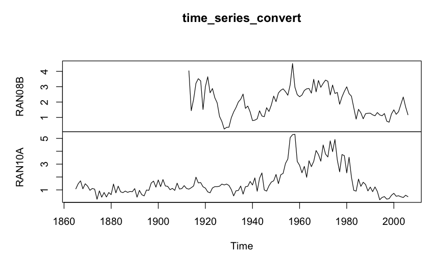

```r
Año_inicio <- as.numeric(rownames(Dat_ringwidth))[1]
time_series_convert <- ts(Dat_ringwidth[,c("RAN08B","RAN10A")],start = Año_inicio, frequency =1 )
plot(time_series_convert)
```

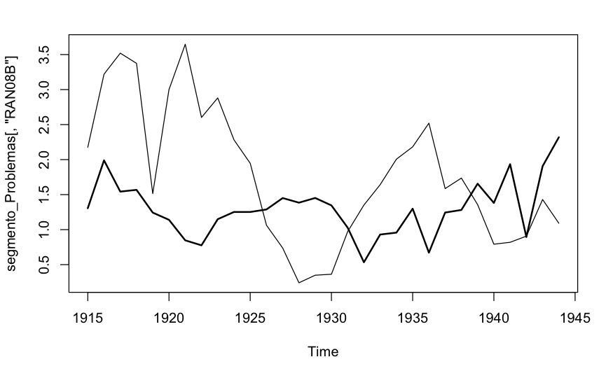

```r
#Selección de un solo segmento de las series

segmento_Problemas <- window(time_series_convert, start=1915, end=1944)
segmento_SIN_Problemas <- window(time_series_convert,1970,1990)

# visualisamos el segmento con problemas con respecto a una seria sin problemas
plot(segmento_Problemas[,"RAN08B"])
lines(segmento_Problemas[,"RAN10A"], lwd=2)
```

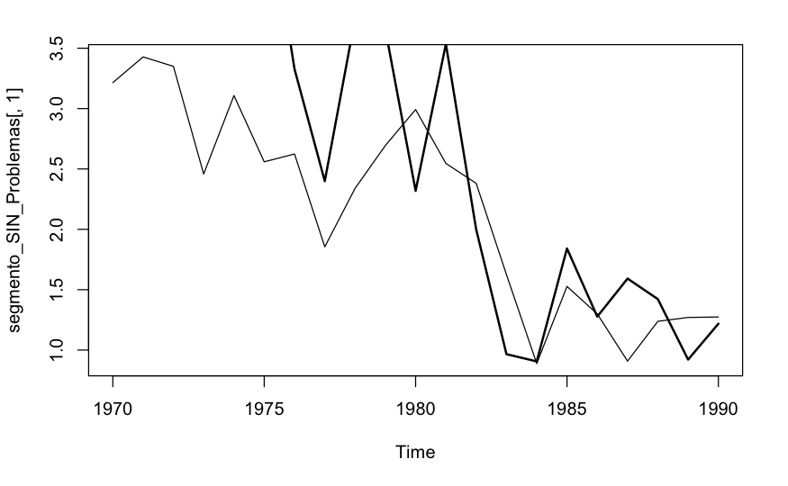

```r
# Tambine se puede identificar la columna por su numero
plot(segmento_SIN_Problemas[,1]) #"RAN08B"
lines(segmento_SIN_Problemas[,2], lwd=2) #"RAN10A"
```

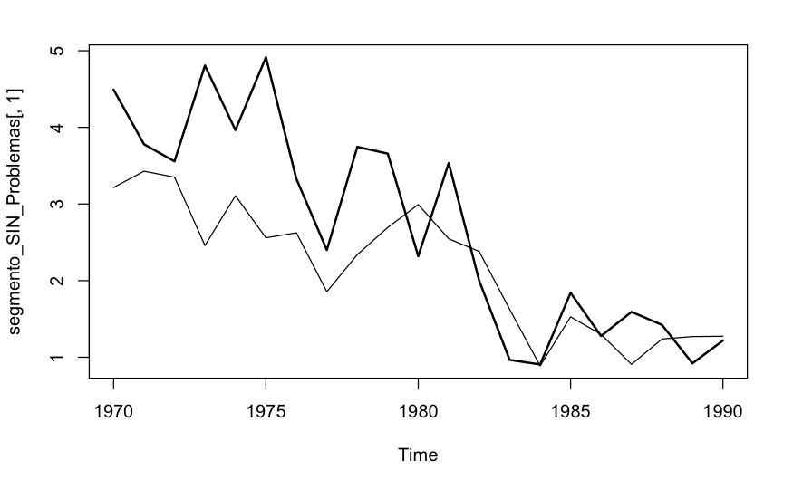

```r
# Ajustamos los  limites del Eje "Y"
plot(segmento_SIN_Problemas[,1], ylim= range(segmento_SIN_Problemas))
lines(segmento_SIN_Problemas[,2], lwd=2)
```